# ExtraaLearn Project

## Context

The EdTech industry has been surging in the past decade immensely, and according to a forecast, the Online Education market would be worth $286.62bn by 2023 with a compound annual growth rate (CAGR) of 10.26% from 2018 to 2023. The modern era of online education has enforced a lot in its growth and expansion beyond any limit. Due to having many dominant features like ease of information sharing, personalized learning experience, transparency of assessment, etc, it is now preferable to traditional education.

In the present scenario due to the Covid-19, the online education sector has witnessed rapid growth and is attracting a lot of new customers. Due to this rapid growth, many new companies have emerged in this industry. With the availability and ease of use of digital marketing resources, companies can reach out to a wider audience with their offerings. The customers who show interest in these offerings are termed as leads. There are various sources of obtaining leads for Edtech companies, like

- The customer interacts with the marketing front on social media or other online platforms.
- The customer browses the website/app and downloads the brochure
- The customer connects through emails for more information.

The company then nurtures these leads and tries to convert them to paid customers. For this, the representative from the organization connects with the lead on call or through email to share further details.

## Objective

ExtraaLearn is an initial stage startup that offers programs on cutting-edge technologies to students and professionals to help them upskill/reskill. With a large number of leads being generated on a regular basis, one of the issues faced by ExtraaLearn is to identify which of the leads are more likely to convert so that they can allocate resources accordingly. You, as a data scientist at ExtraaLearn, have been provided the leads data to:

- Analyze and build an ML model to help identify which leads are more likely to convert to paid customers,
- Find the factors driving the lead conversion process
- Create a profile of the leads which are likely to convert

## Data Description

The data contains the different attributes of leads and their interaction details with ExtraaLearn. The detailed data dictionary is given below.

**Data Dictionary**

- ID: ID of the lead
- age: Age of the lead
- current_occupation: Current occupation of the lead. Values include 'Professional','Unemployed',and 'Student'
- first_interaction: How did the lead first interacted with ExtraaLearn. Values include 'Website', 'Mobile App'
- profile_completed: What percentage of profile has been filled by the lead on the website/mobile app. Values include Low - (0-50%), Medium - (50-75%), High (75-100%)
- website_visits: How many times has a lead visited the website
- time_spent_on_website: Total time spent on the website
- page_views_per_visit: Average number of pages on the website viewed during the visits.
- last_activity: Last interaction between the lead and ExtraaLearn.
  - Email Activity: Seeking for details about program through email, Representative shared information with lead like brochure of program , etc
  - Phone Activity: Had a Phone Conversation with representative, Had conversation over SMS with representative, etc
  - Website Activity: Interacted on live chat with representative, Updated profile on website, etc
- print_media_type1: Flag indicating whether the lead had seen the ad of ExtraaLearn in the Newspaper.
- print_media_type2: Flag indicating whether the lead had seen the ad of ExtraaLearn in the Magazine.
- digital_media: Flag indicating whether the lead had seen the ad of ExtraaLearn on the digital platforms.
- educational_channels: Flag indicating whether the lead had heard about ExtraaLearn in the education channels like online forums, discussion threads, educational websites, etc.
- referral: Flag indicating whether the lead had heard about ExtraaLearn through reference.
- status: Flag indicating whether the lead was converted to a paid customer or not.

## Importing necessary libraries and data

```python
import pandas as pd
import numpy as np
import matplotlib.pyplot as plt
import seaborn as sns

# To build models for prediction
from sklearn import (tree,
                     metrics)

# For tuning the model
from sklearn.feature_selection import SelectFromModel
from sklearn.model_selection import (train_test_split,
                                     GridSearchCV)

# To build the decision tree and get a nice visual
from sklearn.tree import DecisionTreeClassifier

# Importing the ensemble for random forest, bagging, AdaBoost, and Gradient Boost
from sklearn.ensemble import (
                        RandomForestClassifier,
                        BaggingClassifier,
                        AdaBoostClassifier,
                        GradientBoostingClassifier)

# To check model performance
from sklearn.metrics import (
                      classification_report,
                      make_scorer,
                      confusion_matrix,
                      recall_score,
                      precision_score,
                      precision_recall_curve,
                      accuracy_score,
                      f1_score)

# Importing XGBoost Classifier
from xgboost import XGBClassifier

# generate new samples in the feature (status) which are under-represented during training
from imblearn.over_sampling import SMOTE

#import warnings
#warnings.filterwarnings("ignore")
```

```python
# mount local google drive
from google.colab import drive
drive.mount('/content/drive')
```

```python
# Read the EdTech leads dataset file
data = pd.read_csv(
    "/content/drive/MyDrive/Colab Notebooks/Week 5 - Practical Data Science/Elective Project - ExtraaLearn Potential Customer/ExtraaLearn.csv")
```

```python
# Define a function for later use during the EDA
def print_value_counts(df, column, desc):
  """
    Prints the value counts for a specified column in a DataFrame (percentage and counts).

    Prints the percentage of the total sample for each unique value in the specified column.

    Parameters: df (DataFrame): The DataFrame containing the column.
                column (str): The name of the column for which to print value counts.
                desc (str): A description used for to make the output meaningful.
  """

  for i in df[column].unique():
    print(f"{desc}: {i}")
    #print the percentage of converted leads by age group
    print(df.loc[df[column] == i, "status"].value_counts(normalize = True))
    print(df.loc[df[column] == i, "status"].value_counts())
    print('\n')
    print("-" * 50)
    print()

  column_percentages = df.groupby(column).size() / len(df) * 100
  print(f"Percentage of the sample: {column_percentages}")
```

```python
# Function to plot stacked bar plots
# look at the effect of two independent variables on the dependent variable
def stacked_barplot(data, predictor, target):
  # get the number of unique values for predictor
  count = data[predictor].nunique()
  sorter = data[target].value_counts().index[-1]
  tab1 = pd.crosstab(data[predictor], data[target], margins=True).sort_values(by=sorter, ascending=False)
  print(tab1)

  # Normalize the data to see percentages or proportions
  tab2 = pd.crosstab(data[predictor], data[target], normalize='index').sort_values(by=sorter, ascending=False)
  print(tab2)

  tab2.plot(kind = 'bar', stacked=True, figsize=(count + 1, 5))
  # move the legend off the visual
  plt.legend(title=target, loc='best', bbox_to_anchor=(1.0, 1.0))
  plt.show()
```

```python
cat_cols = data.select_dtypes(include=['object', 'category']).columns.tolist()
num_cols = data.select_dtypes(include=np.number).columns.tolist()
```

## Data Overview

- Observations
- Sanity checks

```python
# get the number of rows and columns
# check the data types for each column
# check for missing data
data.info()
```

```
<class 'pandas.core.frame.DataFrame'>
RangeIndex: 4612 entries, 0 to 4611
Data columns (total 15 columns):
 #   Column                 Non-Null Count  Dtype
---  ------                 --------------  -----
 0   ID                     4612 non-null   object
 1   age                    4612 non-null   int64
 2   current_occupation     4612 non-null   object
 3   first_interaction      4612 non-null   object
 4   profile_completed      4612 non-null   object
 5   website_visits         4612 non-null   int64
 6   time_spent_on_website  4612 non-null   int64
 7   page_views_per_visit   4612 non-null   float64
 8   last_activity          4612 non-null   object
 9   print_media_type1      4612 non-null   object
 10  print_media_type2      4612 non-null   object
 11  digital_media          4612 non-null   object
 12  educational_channels   4612 non-null   object
 13  referral               4612 non-null   object
 14  status                 4612 non-null   int64
dtypes: float64(1), int64(4), object(10)
memory usage: 540.6+ KB
```

**Observations:**

- All rows and columns contain non-null data (no missing data)
- 4,612 rows of data (leads)
- 15 features, some of which we will most likely not need

```python
data.describe(include='all').T
```

|  | count | unique | top | freq | mean | std | min | 25% | 50% | 75% | max |
| --- | --- | --- | --- | --- | --- | --- | --- | --- | --- | --- | --- |
| ID | 4612 | 4612 | EXT4612 | 1 | NaN | NaN | NaN | NaN | NaN | NaN | NaN |
| age | 4612.0 | NaN | NaN | NaN | 46.201214 | 13.161454 | 18.0 | 36.0 | 51.0 | 57.0 | 63.0 |
| current_occupation | 4612 | 3 | Professional | 2616 | NaN | NaN | NaN | NaN | NaN | NaN | NaN |
| first_interaction | 4612 | 2 | Website | 2542 | NaN | NaN | NaN | NaN | NaN | NaN | NaN |
| profile_completed | 4612 | 3 | High | 2264 | NaN | NaN | NaN | NaN | NaN | NaN | NaN |
| website_visits | 4612.0 | NaN | NaN | NaN | 3.566782 | 2.829134 | 0.0 | 2.0 | 3.0 | 5.0 | 30.0 |
| time_spent_on_website | 4612.0 | NaN | NaN | NaN | 724.011275 | 743.828683 | 0.0 | 148.75 | 376.0 | 1336.75 | 2537.0 |
| page_views_per_visit | 4612.0 | NaN | NaN | NaN | 3.026126 | 1.968125 | 0.0 | 2.07775 | 2.792 | 3.75625 | 18.434 |
| last_activity | 4612 | 3 | Email Activity | 2278 | NaN | NaN | NaN | NaN | NaN | NaN | NaN |
| print_media_type1 | 4612 | 2 | No | 4115 | NaN | NaN | NaN | NaN | NaN | NaN | NaN |
| print_media_type2 | 4612 | 2 | No | 4379 | NaN | NaN | NaN | NaN | NaN | NaN | NaN |
| digital_media | 4612 | 2 | No | 4085 | NaN | NaN | NaN | NaN | NaN | NaN | NaN |
| educational_channels | 4612 | 2 | No | 3907 | NaN | NaN | NaN | NaN | NaN | NaN | NaN |
| referral | 4612 | 2 | No | 4519 | NaN | NaN | NaN | NaN | NaN | NaN | NaN |
| status | 4612.0 | NaN | NaN | NaN | 0.298569 | 0.45768 | 0.0 | 0.0 | 0.0 | 1.0 | 1.0 |

**Observations:**

- The mean value for status tells me that the data is unbalanced and biased toward leads that do not convert to customers. Under 30% of the leads convert to customers in this dataset.
- I will try the SMOTE function to remedy this later on by oversampling (increase the minority class status == 1).
- I will also try using the class_weight parameter to accomodate for the biased data

```python
data.head()
```

|  | ID | age | current_occupation | first_interaction | profile_completed | website_visits | time_spent_on_website | page_views_per_visit | last_activity | print_media_type1 | print_media_type2 | digital_media | educational_channels | referral | status |
| --- | --- | --- | --- | --- | --- | --- | --- | --- | --- | --- | --- | --- | --- | --- | --- |
| 0 | EXT001 | 57 | Unemployed | Website | High | 7 | 1639 | 1.861 | Website Activity | Yes | No | Yes | No | No | 1 |
| 1 | EXT002 | 56 | Professional | Mobile App | Medium | 2 | 83 | 0.320 | Website Activity | No | No | No | Yes | No | 0 |
| 2 | EXT003 | 52 | Professional | Website | Medium | 3 | 330 | 0.074 | Website Activity | No | No | Yes | No | No | 0 |
| 3 | EXT004 | 53 | Unemployed | Website | High | 4 | 464 | 2.057 | Website Activity | No | No | No | No | No | 1 |
| 4 | EXT005 | 23 | Student | Website | High | 4 | 600 | 16.914 | Email Activity | No | No | No | No | No | 0 |

## Exploratory Data Analysis (EDA)

- EDA is an important part of any project involving data.
- It is important to investigate and understand the data better before building a model with it.
- A few questions have been mentioned below which will help you approach the analysis in the right manner and generate insights from the data.
- A thorough analysis of the data, in addition to the questions mentioned below, should be done.

**Questions**

1. Leads will have different expectations from the outcome of the course and the current occupation may play a key role in getting them to participate in the program. Find out how current occupation affects lead status.
2. The company's first impression on the customer must have an impact. Do the first channels of interaction have an impact on the lead status?
3. The company uses multiple modes to interact with prospects. Which way of interaction works best?
4. The company gets leads from various channels such as print media, digital media, referrals, etc. Which of these channels have the highest lead conversion rate?
5. People browsing the website or mobile application are generally required to create a profile by sharing their personal data before they can access additional information.Does having more details about a prospect increase the chances of conversion?

```python
# Is the lead data balanced or biased?
print(f"Number of leads converted to customers: {data['status'].value_counts()[1]}")
print(f"Number of leads not converted to customers: {data['status'].value_counts()[0]}")
```

```
Number of leads converted to customers: 1377
Number of leads not converted to customers: 3235
```

**Observations:**

- The number of leads that convert to customers is low

```python
# Find out how current occupation affects lead status.
'''
Values:
  'Unemployed'
  'Professional'
  'Student'
'''

print_value_counts(data, 'current_occupation', 'Occupation')
```

```
Occupation: Unemployed
status
0    0.734212
1    0.265788
Name: proportion, dtype: float64
status
0    1058
1     383
Name: count, dtype: int64


--------------------------------------------------

Occupation: Professional
status
0    0.644878
1    0.355122
Name: proportion, dtype: float64
status
0    1687
1     929
Name: count, dtype: int64


--------------------------------------------------

Occupation: Student
status
0    0.882883
1    0.117117
Name: proportion, dtype: float64
status
0    490
1     65
Name: count, dtype: int64


--------------------------------------------------

Percentage of the sample: current_occupation
Professional    56.721596
Student         12.033825
Unemployed      31.244579
dtype: float64
```

**Observations:**

- Professionals have the highest likelyhoood of becoming a customer (∼35.5%) which is great because the majority of their leads are professionals ∼56.7%
- Students are unlikely to become a customer (∼11.7%)

```python
# Find out how the first channels of interaction ('first_interaction') have an impact on the lead status
'''
Values:
  'Website'
  'Mobile App'
'''

print_value_counts(data, 'first_interaction', 'First Interaction')
```

```
First Interaction: Website
status
0    0.54406
1    0.45594
Name: proportion, dtype: float64
status
0    1383
1    1159
Name: count, dtype: int64


--------------------------------------------------

First Interaction: Mobile App
status
0    0.894686
1    0.105314
Name: proportion, dtype: float64
status
0    1852
1     218
Name: count, dtype: int64


--------------------------------------------------

Percentage of the sample: first_interaction
Mobile App    44.882914
Website       55.117086
dtype: float64
```

**Observations:**

- People first exposed to ExtraaLearn on the mobel app convert to customers only ∼10.5%
- ∼45.6% of people first exposed to ExtraaLearn on the website convert to customers. This is an important feature.

```python
# Find out how ExtraaLearn's communication methods ('last_activity') impacts the lead status
'''
Values:
  'Website Activity'
  'Email Activity'
  'Phone Activity'
'''

print_value_counts(data, 'last_activity', 'Last Activity')
```

```
Last Activity: Website Activity
status
0    0.615455
1    0.384545
Name: proportion, dtype: float64
status
0    677
1    423
Name: count, dtype: int64


--------------------------------------------------

Last Activity: Email Activity
status
0    0.696664
1    0.303336
Name: proportion, dtype: float64
status
0    1587
1     691
Name: count, dtype: int64


--------------------------------------------------

Last Activity: Phone Activity
status
0    0.786872
1    0.213128
Name: proportion, dtype: float64
status
0    971
1    263
Name: count, dtype: int64


--------------------------------------------------

Percentage of the sample: last_activity
Email Activity      49.392888
Phone Activity      26.756288
Website Activity    23.850824
dtype: float64
```

**Observations:**

- Website activity seems to be getting more customers to convert.
- The majority of their contact with the customer is by email, which they might want to look at changing.

```python
# ExtraaLearn gets leads from various sources such as
'''
Lead types:
  Newspaper,
  Magazine,
  Digital Media,
  Educational Channels
  Referral
'''

# get some consistency in the column naming convention for lead types (for my own sanity)
data.rename(columns={"print_media_type1": "newspaper_lead"}, inplace=True)
data.rename(columns={"print_media_type2": "magazine_lead"}, inplace=True)
data.rename(columns={"digital_media": "digital_lead"}, inplace=True)
data.rename(columns={"educational_channels": "educational_lead"}, inplace=True)
data.rename(columns={"referral": "referral_lead"}, inplace=True)

# make a list of lead type columns
lead_cols = ['newspaper_lead', 'magazine_lead', 'digital_lead', 'educational_lead', 'referral_lead']

# Which of these sources have the highest lead conversion rate?
# Let's check the status against the different leads
for lead in lead_cols:
  #for lead_status in data[lead].unique():
    print_value_counts(data, lead, lead)
    print('\n')
    print("-" * 50)
    print()
```

```
newspaper_lead: Yes
status
0    0.68008
1    0.31992
Name: proportion, dtype: float64
status
0    338
1    159
Name: count, dtype: int64


--------------------------------------------------

newspaper_lead: No
status
0    0.70401
1    0.29599
Name: proportion, dtype: float64
status
0    2897
1    1218
Name: count, dtype: int64


--------------------------------------------------

Percentage of the sample: newspaper_lead
No     89.223764
Yes    10.776236
dtype: float64


--------------------------------------------------

magazine_lead: No
status
0    0.702672
1    0.297328
Name: proportion, dtype: float64
status
```

[output cut: 114 more lines]

```
status
1    63
0    30
Name: count, dtype: int64


--------------------------------------------------

Percentage of the sample: referral_lead
No     97.983521
Yes     2.016479
dtype: float64


--------------------------------------------------
```

**Observations:**

- There are very few referral leads (∼2% of the sample), but a high percentage of referral leads do convert to customers (∼67.7%)
- The rest of the lead types are not very effective, around 30% of a small number of each type convert to customers.

```python
# How does having more details about a prospect ('profile_completed') impact lead status
'''
Values: these values represent the amount of information a lead has provided about themselves
        in the profile they edited.
  'High'
  'Medium'
  'Low'
'''
print_value_counts(data, 'profile_completed', 'Profile Completed')
```

```
Profile Completed: High
status
0    0.582155
1    0.417845
Name: proportion, dtype: float64
status
0    1318
1     946
Name: count, dtype: int64


--------------------------------------------------

Profile Completed: Medium
status
0    0.811245
1    0.188755
Name: proportion, dtype: float64
status
0    1818
1     423
Name: count, dtype: int64


--------------------------------------------------

Profile Completed: Low
status
0    0.925234
1    0.074766
Name: proportion, dtype: float64
status
0    99
1     8
Name: count, dtype: int64


--------------------------------------------------

Percentage of the sample: profile_completed
High      49.089332
Low        2.320035
Medium    48.590633
dtype: float64
```

**Observations:**

```python
# look at the percentage of leads converted to customers by age group.
for age_group in range(20, int(data['age'].max()), 10):
    # Filter the data for the age group
    total_in_age_group = len(data[(data['age'] >= age_group) & (data['age'] < age_group + 10)])

    # Filter data for the current age group and status 1 (converted to customers)
    filtered_data = data[(data['age'] >= age_group) & (data['age'] < age_group + 10) & (data['status'] == 1)]

    # Calculate percentage for the current age group by comparing all leads for the age group with converted leads
    percentage = (len(filtered_data) / total_in_age_group) * 100 if total_in_age_group else 0
    print(f'There are {total_in_age_group} leads between the age of {age_group} and {age_group + 9} with status 1')
    print(f"Percentage of leads between {age_group} and {age_group + 9} with status 1: {percentage:.2f}%")
    print("-" * 50)
    print()
```

```
There are 516 leads between the age of 20 and 29 with status 1
Percentage of leads between 20 and 29 with status 1: 15.12%
--------------------------------------------------

There are 714 leads between the age of 30 and 39 with status 1
Percentage of leads between 30 and 39 with status 1: 30.39%
--------------------------------------------------

There are 810 leads between the age of 40 and 49 with status 1
Percentage of leads between 40 and 49 with status 1: 30.74%
--------------------------------------------------

There are 2054 leads between the age of 50 and 59 with status 1
Percentage of leads between 50 and 59 with status 1: 34.47%
--------------------------------------------------

There are 371 leads between the age of 60 and 69 with status 1
Percentage of leads between 60 and 69 with status 1: 28.84%
--------------------------------------------------
```

**Observations:**

```python
# How could their first interaction be on the website, yet they have 0 time spent on the website or 0 pages visited?
filtered_data = data[(data['first_interaction'] == 'Website') & ((data['time_spent_on_website'] == 0) | (data['page_views_per_visit'] == 0))]
filtered_data.shape
```

```
(104, 15)
```

**Observations:**

- This is strange and worth inquiring about with whoever built the data collection system at ExtraaLearn

```python
# Checking for duplicate values in the data
num_duplicates = data.duplicated().sum()
if num_duplicates > 0:
  # print how many duplicate rows there are in the dataset
  print(f"There are {num_duplicates} duplicated rows.")
  print("-" * 50)
  print()

  # print the duplicated rows
  # Group by all columns and count occurrences to get an idea how many duplicates for each row there are
  duplication_counts = data.groupby(data.columns.tolist()).size().reset_index(name='duplication_count')

  # Filter to show only rows that are duplicated (duplication_count > 1)
  duplicated_rows_with_counts = duplication_counts[duplication_counts['duplication_count'] > 1]

  # Print the results
  print(duplicated_rows_with_counts)

  # Remove duplicate rows, but keep the first occurance
  data = data.drop_duplicates(keep='first')

else:
  print("No duplicate rows found.")
```

```
No duplicate rows found.
```

```python
# does every lead have at least one lead
filtered_data = data[(data[lead_cols] == 'No').all(axis=1)]
filtered_data.shape
```

```
(2883, 15)
```

```python
# Are there any potential customers
# that documented multiple sources that lead them to ExtraaLearn
data['yes_count'] = (data[lead_cols] == 'Yes').sum(axis=1)
filtered_data = data[data['yes_count'] > 1]

# drop the yes_count column
data.drop('yes_count', axis=1, inplace=True)

filtered_data.shape
```

```
(287, 16)
```

**Observations:**

- There are a majority of leads (2883) that did not document how they found ExtraaLearn
- There are also 287 leads that documented multiple lead types (.i.e newspaper and referral)
- Because of the sparsity of this data, these fields become irrelevant during the decision tree algorithms and will be dropped. I did try engineering one feature from all of these, but it did not effect the performance of the algorithms.

## Visual Analysis of the Data

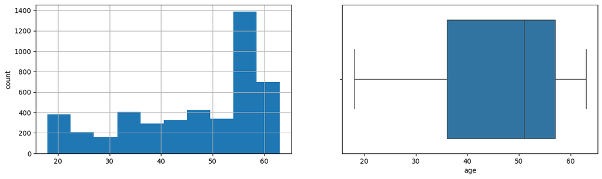

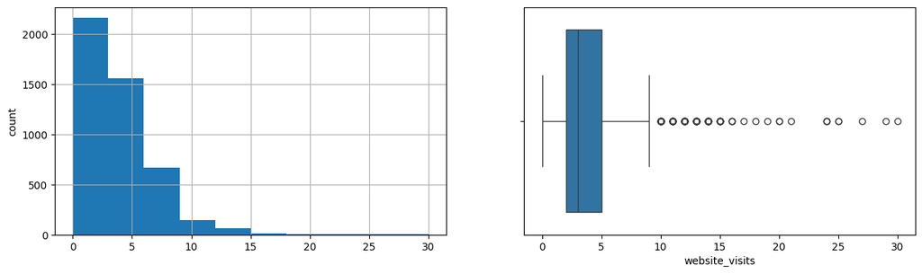

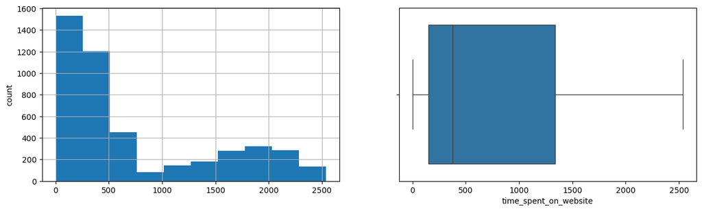

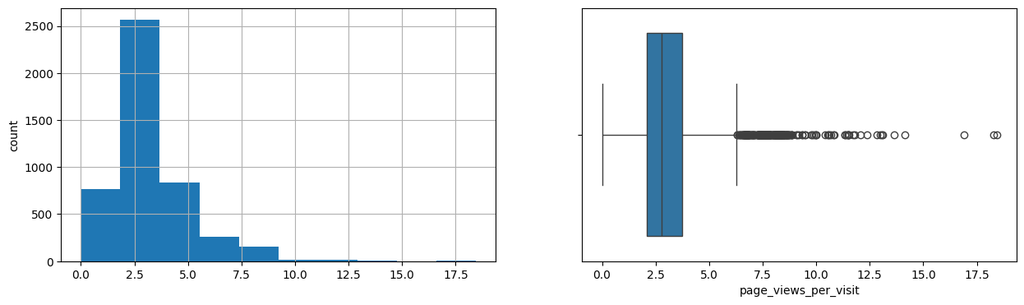

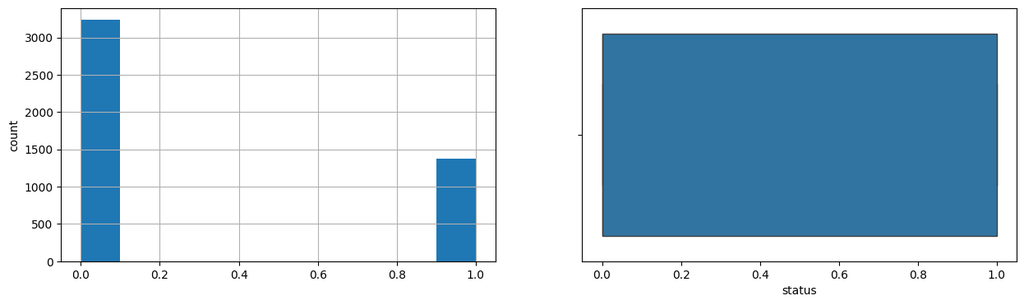

```python
# Creating histograms for all the numerical columns

for col in num_cols:
  # Creating categorical variables
  plt.figure(figsize = (15, 4))
  plt.subplot(1,2,1)
  data[col].hist(bins = 10)
  plt.ylabel('count')

  plt.subplot(1, 2, 2)
  sns.boxplot(x = data[col])
  plt.show()
```

**Observations**

- There are outliers for the website_visits and page_views_per_visit features
- Most of the potential customers in the sample are older (50's)

```python
data.info()
```

```
<class 'pandas.core.frame.DataFrame'>
RangeIndex: 4612 entries, 0 to 4611
Data columns (total 15 columns):
 #   Column                 Non-Null Count  Dtype
---  ------                 --------------  -----
 0   ID                     4612 non-null   object
 1   age                    4612 non-null   int64
 2   current_occupation     4612 non-null   object
 3   first_interaction      4612 non-null   object
 4   profile_completed      4612 non-null   object
 5   website_visits         4612 non-null   int64
 6   time_spent_on_website  4612 non-null   int64
 7   page_views_per_visit   4612 non-null   float64
 8   last_activity          4612 non-null   object
 9   newspaper_lead         4612 non-null   object
 10  magazine_lead          4612 non-null   object
 11  digital_lead           4612 non-null   object
 12  educational_lead       4612 non-null   object
 13  referral_lead          4612 non-null   object
 14  status                 4612 non-null   int64
dtypes: float64(1), int64(4), object(10)
memory usage: 540.6+ KB
```

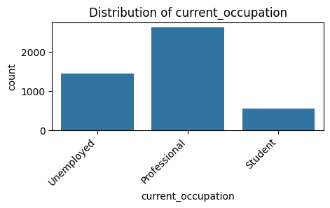

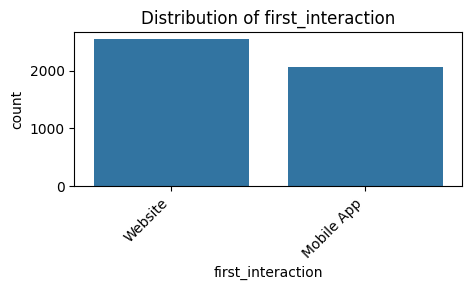

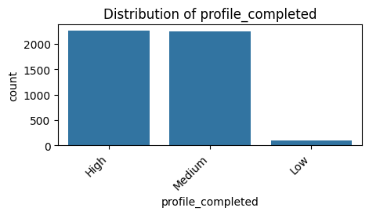

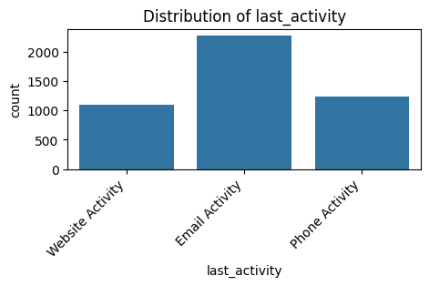

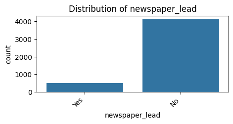

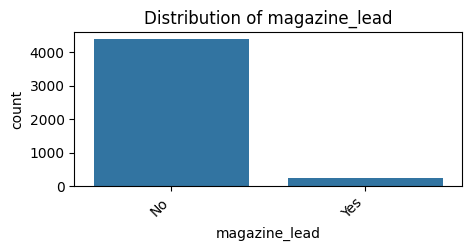

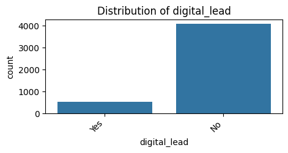

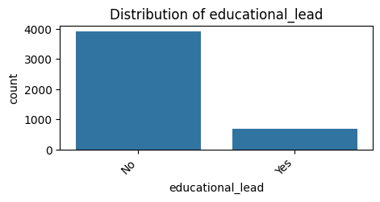

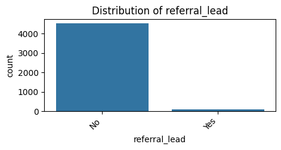

```python
# Creating countplots for all the categorical columns
cat_cols = data.select_dtypes(include=['object', 'category']).columns.tolist()

for col in cat_cols:
  if col != 'ID':
    # Adjust figure size as needed
    plt.figure(figsize=(5, 2))
    sns.countplot(x=col, data=data)
    plt.title(f'Distribution of {col}')
    # Rotate x-axis labels if needed
    plt.xticks(rotation=45, ha='right')
    plt.show()
```

**Observations**

- nothing new here, just a visual of the counts I already looked at.

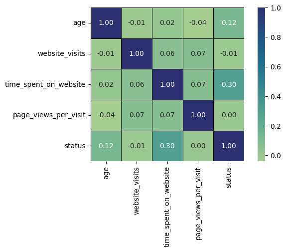

```python
# Creating a correlation heatmap for the numerical features
plt.figure(figsize=(7, 4))
sns.heatmap(data[num_cols].corr(),
            annot=True,
            linecolor='black',
            linewidths = 0.5,
            square = True,
            fmt=".2f",
            cmap="crest")
plt.show()
```

**Observations:**

- the time_spent_on_website has positive correlation with the status of our leads. Luckily our decision trees don't use correlation for splitting data. Even though there isn't strong correlation, some of these could still be key features.

```
status                 0     1   All
current_occupation
All                 3235  1377  4612
Professional        1687   929  2616
Unemployed          1058   383  1441
Student              490    65   555
status                     0         1
current_occupation
Professional        0.644878  0.355122
Unemployed          0.734212  0.265788
Student             0.882883  0.117117
```

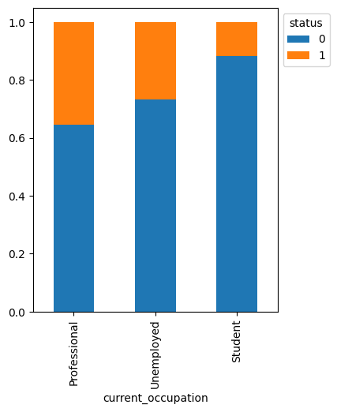

```python
stacked_barplot(data, 'current_occupation', 'status')
```

```
status                0     1   All
profile_completed
All                3235  1377  4612
High               1318   946  2264
Medium             1818   423  2241
Low                  99     8   107
status                    0         1
profile_completed
High               0.582155  0.417845
Medium             0.811245  0.188755
Low                0.925234  0.074766
```

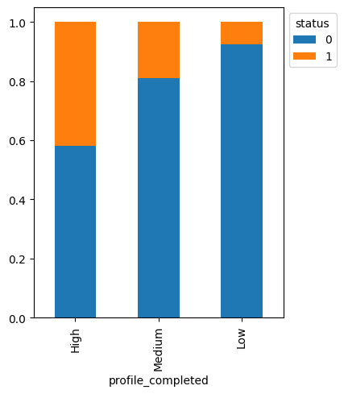

```python
stacked_barplot(data, 'profile_completed', 'status')
```

```
status                0     1   All
first_interaction
All                3235  1377  4612
Website            1383  1159  2542
Mobile App         1852   218  2070
status                    0         1
first_interaction
Website            0.544060  0.455940
Mobile App         0.894686  0.105314
```

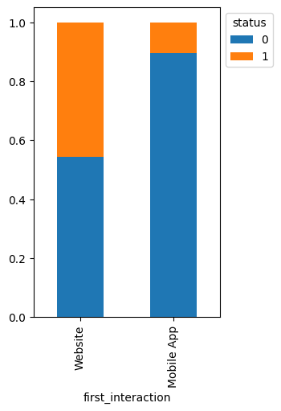

```python
stacked_barplot(data, 'first_interaction', 'status')
```

```
status            0     1   All
referral_lead
All            3235  1377  4612
No             3205  1314  4519
Yes              30    63    93
status                0         1
referral_lead
Yes            0.322581  0.677419
No             0.709228  0.290772
```

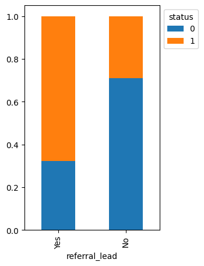

```python
stacked_barplot(data, 'referral_lead', 'status')
```

**Observations**

- Phone calls do not help convert many leads to customers, while web or email activity perform better.
- The mobile app is not bringing in customers, this might need to be looked at by the development team. Those that find ExtraaLearn on the website convert to customers at a much higher rate.
- The more profile information entered by a lead, the more likely that lead is to convert to a customer. Make this easy for them so ExtraaLearn can then reach out via email.
- current students and young people in general are not good candidates to become ExraaLearn customers. Professionals should be targeted.
- none of the advertising has a huge impact on leads converting to customers This is strange because leads are finding the website and web activity plays a big part in leads converting to customers. I'm wondering how this data is collected and whether it is something many leads are just missing.
- referrals convert to customers often, but there are not many referrals in this sample.

## Data Preprocessing

- Missing value treatment (if needed)
- Feature engineering (if needed)
- Outlier detection and treatment (if needed)
- Preparing data for modeling
- Any other preprocessing steps (if needed)

```python
# From the boxplots above...
# there are outliers to be dealt with
'''
  'website_visits'
  'page_views_per_visit'
'''

# Define a function to remove the bottom 10% of the data (outliers are on the high side)
def remove_outliers(df, column):

  q1 = df[column].quantile(0.10)
  q3 = df[column].quantile(0.90)
  iqr = q3 - q1
  lower_bound = q1 - 1.5 * iqr
  upper_bound = q3 + 1.5 * iqr
  # only include the leads that are in the lower 90% for the feature,
  # unless the outlier is a converted customer
  df_filtered = df[(df[column] <= upper_bound) | (df['status'] == 1)]
  return df_filtered

# remove entire row for outliers of type website_visit and page_views_per_visit
data = remove_outliers(data, 'website_visits')
data = remove_outliers(data, 'page_views_per_visit')
data.shape
```

```
(4597, 15)
```

**Observations:**

- There were 4612 leads in the sample.
- 15 leads were removed due to outliers in the website_visits and page_views_per_visit fields

```python
# Map all the lead fields and convert them to integer type field
'''
  Values mapped:
    'No': 0
    'Yes': 1
  Columns mapped:
    'newspaper_lead'
    'magazine_lead'
    'digital_lead'
    'educational_lead'
    'referral_lead']
'''

for col in lead_cols:
  data[col] = data[col].map({'No': 0, 'Yes': 1})
```

```python
# try engineering one useful feature and then drop all the lead columns
# put all the leads into one lead_type column based on the types of lead
'''
  Values:
    No lead type = 0
    lead type is either newspaper, magazine, digital, or educational = 1
    More than one lead type (excluding referral)= 3
    lead type is referral = 3
    More than one lead type (including referral) = 4
'''

# Create the 'lead_type' column based on the conditions
# Initialize with default value 0 (none of the lead columns are 'Yes' - majority)
data['lead_type'] = 0

# If any of the other lead columns are 'Yes', assign 1 to lead_type
data.loc[(data[lead_cols[:-1]] == 1).any(axis=1), 'lead_type'] = 1

# If more than one lead type is 'Yes' (excluding referral), assign 2 to lead_type
data.loc[(data[lead_cols].sum(axis=1) > 1) & (data['referral_lead'] == 0), 'lead_type'] = 2

# If 'referral_lead' is 'Yes', assign 1 to lead_type
data.loc[data['referral_lead'] == 1, 'lead_type'] = 3

# If referral and another lead type are 'Yes', assign 4 to lead_type
data.loc[(data[lead_cols].sum(axis=1) > 1) & (data['referral_lead'] == 1), 'lead_type'] = 4

# drop the lead_cols
data.drop(lead_cols, axis=1, inplace=True)
```

```python
# Look at the number of different values for each column and drop anything unique
for column in data.columns:
    if data[column].value_counts().max() <= 1:
        # if every value in the column is unique, then we don't need the column
        # because it doesn't add anything unique to our analysis
        print(f"Drop this column: {column}")
        data.drop(column, axis=1, inplace=True)
        print(data.shape)
        print("-" * 50)
        print()
```

```
Drop this column: ID
(4597, 10)
--------------------------------------------------
```

```python
# encode the profile_completed field 0/Low 1/Medium and 2/High and convert field to integer type
data['profile_completed'] = data['profile_completed'].map({'Low': 0, 'Medium': 1, 'High': 2})
```

```python
data.info()
```

```
<class 'pandas.core.frame.DataFrame'>
Index: 4597 entries, 0 to 4611
Data columns (total 10 columns):
 #   Column                 Non-Null Count  Dtype
---  ------                 --------------  -----
 0   age                    4597 non-null   int64
 1   current_occupation     4597 non-null   object
 2   first_interaction      4597 non-null   object
 3   profile_completed      4597 non-null   int64
 4   website_visits         4597 non-null   int64
 5   time_spent_on_website  4597 non-null   int64
 6   page_views_per_visit   4597 non-null   float64
 7   last_activity          4597 non-null   object
 8   status                 4597 non-null   int64
 9   lead_type              4597 non-null   int64
dtypes: float64(1), int64(6), object(3)
memory usage: 395.1+ KB
```

```python
# Separating independent variables and the target variable
x = data.drop('status',axis=1)
y = data['status']

# Creating dummy variables for the categorical columns
cat_cols = x.select_dtypes(include=['object', 'category']).columns.tolist()
x = pd.get_dummies(x, columns = cat_cols, drop_first = True, dtype = int)
```

```python
x.info()
```

```
<class 'pandas.core.frame.DataFrame'>
Index: 4597 entries, 0 to 4611
Data columns (total 11 columns):
 #   Column                          Non-Null Count  Dtype
---  ------                          --------------  -----
 0   age                             4597 non-null   int64
 1   profile_completed               4597 non-null   int64
 2   website_visits                  4597 non-null   int64
 3   time_spent_on_website           4597 non-null   int64
 4   page_views_per_visit            4597 non-null   float64
 5   lead_type                       4597 non-null   int64
 6   current_occupation_Student      4597 non-null   int64
 7   current_occupation_Unemployed   4597 non-null   int64
 8   first_interaction_Website       4597 non-null   int64
 9   last_activity_Phone Activity    4597 non-null   int64
 10  last_activity_Website Activity  4597 non-null   int64
dtypes: float64(1), int64(10)
memory usage: 431.0 KB
```

```python
# Splitting the dataset into train and test datasets
# 30% of the sample will be used for testing
# 70% of the sample will be used for training
x_train, x_test, y_train, y_test = train_test_split(x, y, test_size = 0.3, shuffle = True, random_state = 1, stratify = y)

# Consider using the SMOTE function to oversample the data and
# make up for the bias where status == 0 over 70% of the time
# use the smote function to balance the data (same amount of leads with status 0 and 1)
# This gives me another set of test data to compare with the regular split
smote = SMOTE(random_state=1)
x_train_resampled, y_train_resampled = smote.fit_resample(x_train, y_train)

# Checking the shape of the train and test data
print("Shape of Training set : ", x_train.shape)
print("Shape of test set : ", x_test.shape)

print("Original class distribution:")
print(y_train.value_counts())

print("\nResampled class distribution:")
print(y_train_resampled.value_counts())
```

```
Shape of Training set :  (3217, 11)
Shape of test set :  (1380, 11)
Original class distribution:
status
0    2253
1     964
Name: count, dtype: int64

Resampled class distribution:
status
0    2253
1    2253
Name: count, dtype: int64
```

## Building a Decision Tree model

```python
# Function to compute different metrics to check classification performance

def model_performance_metrics(model, predictors, target):
    '''
      Print the classification report and return the scores
    '''

    # Predicting using the independent variables
    pred = model.predict(predictors)
    recall = recall_score(target, pred,average = 'binary')
    precision = precision_score(target, pred, average = 'binary')
    acc = accuracy_score(target, pred)
    f1 = f1_score(target, pred, average='binary')

    # Creating a dataframe of metrics to report out
    df_perf = pd.DataFrame({"Precision":  precision,
                            "Recall": recall,
                            "Accuracy":  acc,
                            "F1_Score": f1}, index = [0],)

    return df_perf
```

```python
# Function to print the classification report and get confusion matrix in a proper format

def model_confusion_matrix(actual, predicted):
  '''
    Function to check classification model performance
    Print the classification report and confusion matrix
    Return metric score
  '''

  cm = confusion_matrix(actual, predicted)

  plt.figure(figsize = (8, 5))

  sns.heatmap(cm, annot = True,  fmt = '.2f', xticklabels = ['Not Converted', 'Converted'], yticklabels = ['Not Converted', 'Converted'])

  plt.ylabel('Actual')
  plt.xlabel('Predicted')
  plt.show()
```

```python
# Decision Tree Classifier
# try using the built in class weight parameter in the decisioin tree class to
# handle the unblanced data for the status field (along with the oversampled training data)
# Use the class_weight hyperparameter to handle the unbalanced data for the status field
# class_weight = {0: 0.3, 1: 0.7} counters unbalanced data because status = 1 occurs only about 30% of the time
dt_classifier = DecisionTreeClassifier(random_state = 1)

# Fitting the model
dt_classifier.fit(x_train, y_train)

# Model performance evaluation on the training data
dtree_train_metrics = model_performance_metrics(dt_classifier,x_train,y_train)
dtree_train_metrics
```

|  | Precision | Recall | Accuracy | F1_Score |
| --- | --- | --- | --- | --- |
| 0 | 1.0 | 0.997925 | 0.999378 | 0.998962 |

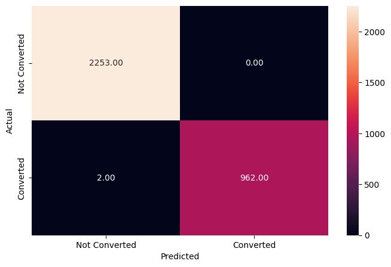

```python
# lets get a visual of where things went right and wrong
model_confusion_matrix(y_train, dt_classifier.predict(x_train))
```

**Observations**

- pretty awesome results, most likely overfitting because of the depth of the tree being unlimited.

```python
# Model performance evaluation of classification on test data
dtree_test_metrics = model_performance_metrics(dt_classifier,x_test,y_test)
dtree_test_metrics
```

|  | Precision | Recall | Accuracy | F1_Score |
| --- | --- | --- | --- | --- |
| 0 | 0.710723 | 0.690073 | 0.823188 | 0.700246 |

[figure not shown]

```python
# lets get a visual of where things went right and wrong
model_confusion_matrix(y_test, dt_classifier.predict(x_test))
```

**Observations:**

- Accuracy is good because the tree is finding lots of lead that have not converted to customers. This is most likely due to the status field being unbalanced in the sample.

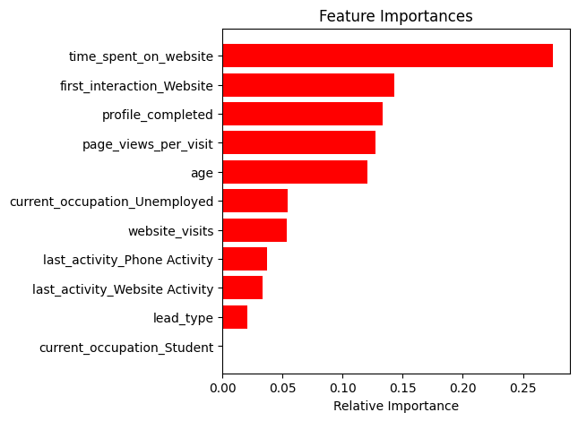

```python
# Plotting the feature importance
features = list(x.columns)

# calculates the relative importance of each feature in making predictions.
importances = dt_classifier.feature_importances_

# obtain the indices that would sort an array of feature importances.
indices = np.argsort(importances)

# build the figure and name the features along the y-axis
plt.figure(figsize = (5, 5))
plt.title('Feature Importances')
plt.barh(range(len(indices)), importances[indices], color = 'red', align = 'center')
plt.yticks(range(len(indices)), [features[i] for i in indices])
plt.xlabel('Relative Importance')

plt.show()
```

## Model Performance evaluation and improvement

- Deal with overfitting on the training data
- Deal with unbalanced data (less than 30% of the leads have status == 1)
- Play around with hyperparameter tuning and cross-validation:
  - max_depth
  - max_features
  - min_samples_leaf
  - criterion
  - class_weight
- try ensamble learning methods
  - bagging
  - random forest
  - boosting

```python
# Decision Tree Classifier - perform cross-validation and hyperparameter tuning

# Use the class_weight hyperparameter to handle the unbalanced data for the status field
# class_weight = {0: 0.3, 1: 0.7} counters unbalanced data because status = 1 occurs only about 30% of the time
dt_tuned_classifier = DecisionTreeClassifier(random_state = 1,
                                             class_weight = {0: 0.3, 1: 0.7})

# Grid of parameters to choose from (3840 combinations)
parameters = {'max_depth': [None, 2, 4, 6, 8, 10],
              'criterion': ['gini', 'entropy'],
              'min_samples_leaf': [4, 6, 8, 10],
              'max_features': ['sqrt', 'log2', 2, 4],
              'min_samples_split': [2, 4, 6, 8, 10],
              'max_leaf_nodes': [5, 10, 15, 20]
             }

# Type of scoring used to compare parameter combinations - f1_score
# the f1_Score will give me a combination of precision and recall
scorer = metrics.make_scorer(f1_score, pos_label = 1)

# Run the grid search for hyperparameter tuning
# use cross-validation with 5 folds - TRAIN 5 MODELS - use the average
grid_obj = GridSearchCV(dt_tuned_classifier, parameters, scoring = scorer, cv = 5)

# Use the oversampled data set
grid_obj = grid_obj.fit(x_train, y_train)

# Set the classifier to the best combination of parameters
dt_tuned_classifier = grid_obj.best_estimator_

# Fit the best algorithm to the data
dt_tuned_classifier.fit(x_train, y_train)
```

```
DecisionTreeClassifier(class_weight={0: 0.3, 1: 0.7}, max_depth=8,
                       max_features='sqrt', max_leaf_nodes=20,
                       min_samples_leaf=6, random_state=1)
```

```python
# Model performance evaluation on the training data
dtree_train_metrics = model_performance_metrics(dt_tuned_classifier,x_train,y_train)
dtree_train_metrics
```

|  | Precision | Recall | Accuracy | F1_Score |
| --- | --- | --- | --- | --- |
| 0 | 0.766497 | 0.78564 | 0.864386 | 0.775951 |

```python
# Model performance evaluation on the training data
dtree_train_metrics = model_performance_metrics(dt_tuned_classifier,x_test,y_test)
dtree_train_metrics
```

|  | Precision | Recall | Accuracy | F1_Score |
| --- | --- | --- | --- | --- |
| 0 | 0.755 | 0.73301 | 0.849057 | 0.743842 |

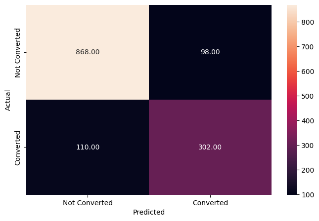

```python
# lets get a visual of where things went right and wrong
model_confusion_matrix(y_test, dt_tuned_classifier.predict(x_test))
```

**Observations:**

- The tuned classifier took care of the overfitting problem. Setting the max_depth most likely helped with that.
- The accuracy is good because we are predicting almost 90% of the leads that will not convert.
- Recall might be acceptable and worth having a conversation with management. We are predicting 73% of the converted customers. The potential loss of 110 customers because the algorithm thought they would not convert is a concern.

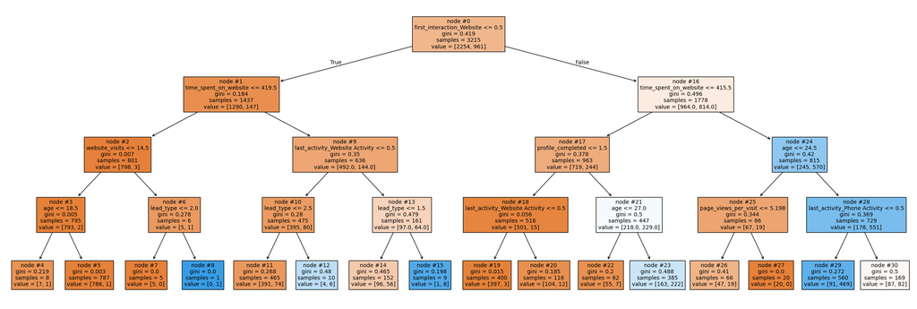

```python
# lets get a visual picture of the tree and its nodes to depth 4
features = list(x.columns)

# Building the model with max_depth=3
dt_classifier_visualize = DecisionTreeClassifier(random_state = 1, max_depth=4)

# Fitting the model
dt_classifier_visualize.fit(x_train, y_train)

plt.figure(figsize = (30, 10))
tree.plot_tree(dt_classifier_visualize,
               feature_names = features,
               filled = True,
               fontsize = 10,
               node_ids = True,
               class_names = None)

plt.show()
```

**Observations:**

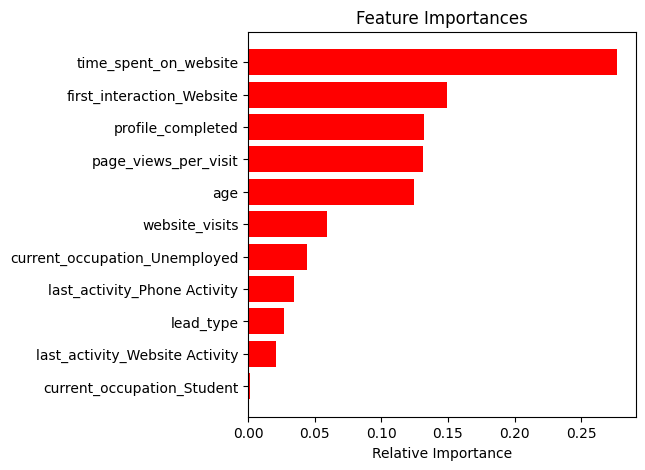

```python
# Plotting the feature importance for the decision tree
features = list(x.columns)

# calculates the relative importance of each feature in making predictions.
importances = dt_classifier.feature_importances_

# obtain the indices that would sort an array of feature importances.
indices = np.argsort(importances)

# build the figure and name the features along the y-axis
plt.figure(figsize = (5, 5))
plt.title('Feature Importances')
plt.barh(range(len(indices)), importances[indices], color = 'red', align = 'center')
plt.yticks(range(len(indices)), [features[i] for i in indices])
plt.xlabel('Relative Importance')

plt.show()
```

**Observations:**

- web activity matters
- The amount of the profile page completed is important
- The age of the lead is important

```python
# start the ensamble learning technique
# techniques that combine multiple machine learning models to produce a
# more accurate prediction than any single model alone

# Bagging Classifier
bagging_estimator = BaggingClassifier(random_state = 1,
                                      n_estimators=10,
                                      max_samples = 1.0,
                                      bootstrap = True,
                                      max_features = 5,
                                      bootstrap_features = False)

# Fitting the model
bagging_estimator.fit(x_train, y_train)
```

```
BaggingClassifier(max_features=5, random_state=1)
```

```python
# Model Performance on the training data
bagging_estimator_perf_test = model_performance_metrics(bagging_estimator, x_train, y_train)
bagging_estimator_perf_test
```

|  | Precision | Recall | Accuracy | F1_Score |
| --- | --- | --- | --- | --- |
| 0 | 0.991266 | 0.944849 | 0.981026 | 0.967501 |

```python
# Model Performance on the test data
bagging_estimator_perf_test = model_performance_metrics(bagging_estimator, x_test, y_test)
bagging_estimator_perf_test
```

|  | Precision | Recall | Accuracy | F1_Score |
| --- | --- | --- | --- | --- |
| 0 | 0.72381 | 0.368932 | 0.769231 | 0.488746 |

**Observations:**

- The model is overfit on the training data and performs poorly on the test data.
- Try using the oversampled data set to improve performance in case it is just the unbalanced data throwing it off.

```python
# start the ensamble learning technique
# techniques that combine multiple machine learning models to produce a
# more accurate prediction than any single model alone

# Bagging Classifier
bagging_estimator = BaggingClassifier(random_state = 1,
                                      n_estimators=10,
                                      max_samples = 1.0,
                                      bootstrap = True,
                                      max_features = 5,
                                      bootstrap_features = False)

# Fitting the model
bagging_estimator.fit(x_train_resampled, y_train_resampled)
```

```
BaggingClassifier(max_features=5, random_state=1)
```

```python
# Model Performance on the training data
bagging_estimator_perf_test = model_performance_metrics(bagging_estimator, x_train_resampled, y_train_resampled)
bagging_estimator_perf_test
```

|  | Precision | Recall | Accuracy | F1_Score |
| --- | --- | --- | --- | --- |
| 0 | 0.985385 | 0.987134 | 0.986247 | 0.986259 |

```python
# Model Performance on the test data
bagging_estimator_perf_test = model_performance_metrics(bagging_estimator, x_test, y_test)
bagging_estimator_perf_test
```

|  | Precision | Recall | Accuracy | F1_Score |
| --- | --- | --- | --- | --- |
| 0 | 0.549569 | 0.618932 | 0.734398 | 0.582192 |

**Observations:**

- The oversampled data helped, but the training data is still overfitting.
- I could play with hyperparameter tuning, but I'm ready to move on to the random forest which will do some bagging too. I'll play around with hyperparameter tuning on the randomforest model

## Building a Random Forest model

```python
# Random Forest Classifier
# Random Forests tend not to overfit (hopefully)
rf_classifier = RandomForestClassifier(n_estimators = 110,
                                       class_weight= {0: 0.3, 1: 0.7},
                                       random_state = 1,
                                       criterion='entropy',
                                       min_samples_leaf = 4,
                                       max_features = 5,
                                       max_depth = 6)

# Fitting the model to the training data
rf_classifier.fit(x_train, y_train)

# Model Performance on the train data
dtree_train = model_performance_metrics(rf_classifier,x_train,y_train)
dtree_train
```

|  | Precision | Recall | Accuracy | F1_Score |
| --- | --- | --- | --- | --- |
| 0 | 0.716123 | 0.868887 | 0.857854 | 0.785143 |

```python
# Model Performance on the test data
dtree_test = model_performance_metrics(rf_classifier,x_test,y_test)
dtree_test
```

|  | Precision | Recall | Accuracy | F1_Score |
| --- | --- | --- | --- | --- |
| 0 | 0.715812 | 0.813107 | 0.847605 | 0.761364 |

[figure not shown]

```python
# lets get a visual of where things went right and wrong
model_confusion_matrix(y_test, rf_classifier.predict(x_test))
```

**Observations:**

- This model performed better than the bagging and decision tree classifiers.
- The recall and F1_Score are better than the tuned decision tree
- The precision is not as good as the tuned decision tree
- Accuracy is about the same as the tuned decision tree.